# Key Takeaways from the Descriptive Phase

## Small PPSF Decision Tree If-Then Rules

```python
def extract_leaf_rules(tree, feature_names):

    tree_ = tree.tree_
    feature_name = [
        feature_names[i] if i != _tree.TREE_UNDEFINED else "undefined!"
        for i in tree_.feature
    ]

    paths = []
    path = []

    def recurse(node, path, paths):
        if tree_.feature[node] != _tree.TREE_UNDEFINED:
            name = feature_name[node]
            threshold = tree_.threshold[node]
            left_path = list(path)
            left_path.append(f"{name} <= {threshold:.1f}")
            recurse(tree_.children_left[node], left_path, paths)

            right_path = list(path)
            right_path.append(f"{name} > {threshold:.1f}")
            recurse(tree_.children_right[node], right_path, paths)
        else:
            value = tree_.value[node][0][0]
            rule = " AND ".join(path)
            paths.append((rule, round(value, 3)))

    recurse(0, path, paths)
    return paths

# Run and print
rules = extract_leaf_rules(tree_small, list(X_small.columns))
for rule, value in rules:
    print(f"If {rule} → PPSF ≈ {value}")
```

```
If Complex_The Landon <= 0.5 AND Complex_Bond on Mint <= 0.5 AND Complex_Solis Midtown <= 0.5 → PPSF ≈ 2.334
If Complex_The Landon <= 0.5 AND Complex_Bond on Mint <= 0.5 AND Complex_Solis Midtown > 0.5 → PPSF ≈ 2.899
If Complex_The Landon <= 0.5 AND Complex_Bond on Mint > 0.5 AND Sqft <= 713.0 → PPSF ≈ 3.272
If Complex_The Landon <= 0.5 AND Complex_Bond on Mint > 0.5 AND Sqft > 713.0 → PPSF ≈ 3.065
If Complex_The Landon > 0.5 → PPSF ≈ 1.471
```

Charlotte’s PPSF decision tree for small units (< 1010 sqft) is expressed here as a series of rule paths, showing exactly how the model assigns average price per square foot. Each branch represents a decision point, and each leaf corresponds to a predicted outcome. The structure highlights how categorical anchors dominate the segmentation, with square footage appearing only once as a refinement.

The first split isolates The Landon, which consistently defines the SouthPark value tier at $\$1.47$ PPSF. Units outside The Landon divide further by complex identity. If neither Bond on Mint nor Solis Midtown are present, the model assigns a mid‑range PPSF of $\$2.33$. Solis Midtown creates its own premium pathway, averaging $\$2.90$. Bond on Mint anchors Uptown luxury, with square footage introducing a threshold effect: smaller units at or below 713 sqft average $\$3.27$ PPSF, while larger layouts average $\$3.07$.

This rule‑based view reveals the hierarchy of drivers. Complex identity is the primary filter, Bond on Mint and Solis Midtown define premium pathways, and square footage refines only within Bond on Mint. Bedrooms, bathrooms, amenities, and neighborhood indicators are excluded entirely, underscoring that compact‑unit PPSF is determined by brand identity and size thresholds rather than by features or location labels.

For stakeholders, this format serves as the model’s rulebook. It provides a transparent, step‑by‑step account of how predictions are made, complementing persona tables and narrative summaries by exposing the mechanics behind Charlotte’s small‑unit pricing tiers.

## Conclusion for Small PPSF Decision Tree

Charlotte’s PPSF decision tree for small units ultimately shows that compact rental pricing is shaped less by granular features and more by categorical anchors. Complex identity dominates the segmentation, with The Landon, Bond on Mint, and Solis Midtown defining clear tiers, while square footage plays only a minor supporting role. Bedrooms, amenities, and neighborhood indicators are excluded entirely, reinforcing that brand identity and size thresholds are the decisive factors in how PPSF is set.

For stakeholders, the conclusion is straightforward. The tree provides a transparent, rule‑based map of Charlotte’s small‑unit market, distilling statistical complexity into intuitive personas that are easy to interpret and act upon. Regression offers precision by quantifying global effects, but the decision tree translates those effects into recognizable profiles that clarify how value clusters across complexes and submarkets. Together, the models highlight that compact rentals are priced through identity and efficiency signals rather than through detailed unit attributes, giving both analytical rigor and narrative clarity to Charlotte’s rental landscape.

# PPSF Large Decision Tree

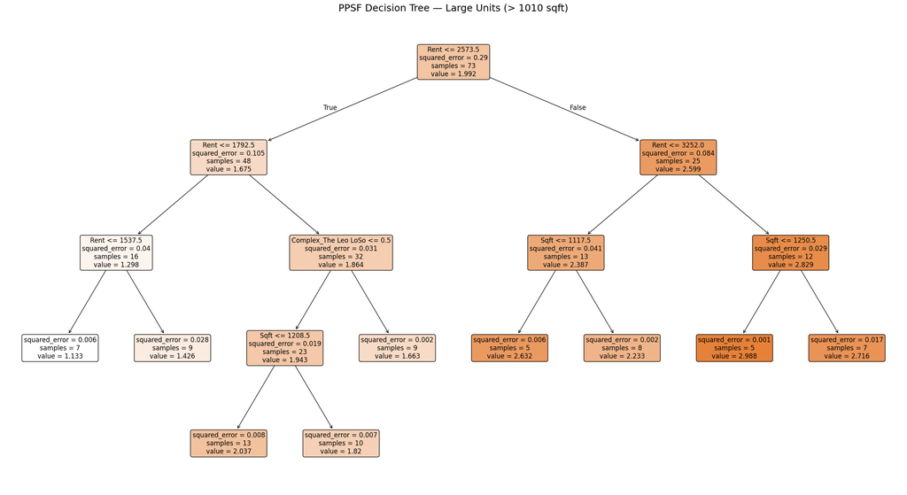

```
🔍 Feature Importances — Large Units (> 1010 sqft):

Rent                            0.927886
Sqft                            0.047403
Complex_The Leo LoSo            0.024711
Bathrooms                       0.000000
Bedrooms                        0.000000
laundry                         0.000000
gym                             0.000000
pool                            0.000000
parking                         0.000000
ev_charging                     0.000000
elevator                        0.000000
pets                            0.000000
wifi                            0.000000
wifi_common                     0.000000
trash_pickup                    0.000000
renters_insurance               0.000000
packages                        0.000000
recycling                       0.000000
Complex_Bond on Mint            0.000000
secure_access                   0.000000
Complex_Broadstone Craft        0.000000
Complex_Ello House              0.000000
Complex_Moderna Liberty Row     0.000000
Complex_Hawkins Press           0.000000
Complex_Novel Mallard Creek     0.000000
Complex_Solis Midtown           0.000000
Complex_The Henry               0.000000
Complex_The Landon              0.000000
Complex_The Perch               0.000000
Complex_Tyvola Tapestry         0.000000
Neighborhood_NoDa               0.000000
Neighborhood_South End          0.000000
Neighborhood_SouthPark          0.000000
Neighborhood_University City    0.000000
Neighborhood_Uptown             0.000000
Neighborhood_West Charlotte     0.000000
dtype: float64

📈 R² for PPSF Tree — Large Units: 0.916
```

```python
# Drop non-predictive or text-heavy columns
apt_cleaned = apt.drop(columns=['Address', 'Unit_Variant', 'Amenities', 'Website'])

# Encode categorical columns
apt_encoded = pd.get_dummies(apt_cleaned, columns=['Complex', 'Neighborhood'], drop_first=False)

# Filter for large units (> 1010 sqft)
apt_large = apt_encoded[apt_encoded['Sqft'] > 1010]

# Define target and features for PPSF (large units)
y_large = apt_large['price_per_sqft']
X_large = apt_large.drop(columns=['price_per_sqft'])

# Train/test split (distinct variable names for large units)
X_train_l, X_test_l, y_train_l, y_test_l = train_test_split(
    X_large, y_large, test_size=0.2, random_state=42
)

# Fit decision tree for PPSF (large units)
tree_large = DecisionTreeRegressor(max_depth=4, min_samples_leaf=5, random_state=42)
tree_large.fit(X_train_l, y_train_l)

# Visualize the tree
plt.figure(figsize=(30, 16))
plot_tree(
    tree_large,
    feature_names=X_large.columns,
    filled=True,
    rounded=True,
    fontsize=12
)
plt.title("PPSF Decision Tree — Large Units (> 1010 sqft)", fontsize=18)
plt.show()

# Feature importance
importances_large = pd.Series(tree_large.feature_importances_, index=X_large.columns)
print("\n🔍 Feature Importances — Large Units (> 1010 sqft):\n")
print(importances_large.sort_values(ascending=False))

# R² score for PPSF tree (large units)
r2_tree_large = tree_large.score(X_test_l, y_test_l)
print(f"\n📈 R² for PPSF Tree — Large Units: {r2_tree_large:.3f}")
```

This rent dominant structure produces a highly accurate model, with an R² of 0.916. It suggests that for larger units, asking rent is not just a proxy for PPSF, it is the signal. The tree does not need to infer value from amenities or layout because rent already encodes those effects. In contrast to the small unit tree, which segments by identity and size, the large unit tree behaves more like a pricing validator. If rent is high, PPSF will be high, regardless of where the unit is or what it offers.

For stakeholders, this model serves as a diagnostic tool. It confirms that rent is the primary driver of PPSF for large units, and that additional features offer no incremental predictive value. It also reinforces the idea that pricing logic shifts with unit size. What matters for small units, such as identity and compactness, is not what matters for large ones, where rent thresholds take precedence. This insight can guide both pricing strategy and feature prioritization across Charlotte’s rental landscape.